# Exercise #3

Fortgeschrittene Statistische Software für NF

Aldini Lukas (11931856)  
2024-06-05

## General Remarks

- You can submit your solutions in teams of up to 3 students.
- Include all your team-member’s names and student numbers (Martrikelnummern) in the `authors` field.
- Please use the exercise template document to work on and submit your results.
- Use a level 2 heading for each new exercise and answer each subtask next to it’s bullet point or use a new level 3 heading if you want.
- Always render the R code for your solutions and make sure to include the resulting data in your rendered document.
  - Make sure to not print more than 10 rows of data (unless specifically instructed to).
- Always submit both the rendered document(s) as well as your source Rmarkdown document. Submit the files separately on moodle, **not** as a zip archive.

## Exercise 1: Initializing git (4 Points)

For this whole exercise sheet we will be tracking all our changes to it in git.

1. Start by initializing a new R project with git support, called `2024-exeRcise-sheet-3`. If you forgot how to do this, you can follow this [guide](https://malikaihle.github.io/Introduction-RStudio-Git-GitHub/rstudio_project.html).
2. Commit the files generated by Rstudio.
3. For all of the following tasks in this exercise sheet we ask you to always commit your changes after finishing each subtask e.g. create a commit after task *1d*, *1e* etc.

> Note: This applies only to answers that have text or code as their answer. If you complete tasks in a different order or forget to commit one, this is no problem. If you change your answers you can just create multiple commits to track the changes.
4. Name 2 strengths and 2 weaknesses of git. (Don’t forget to create a commit after this answer, see *1c*)

### Task 1) - Subtask d)

- Strenghts
  - One of the most important strengths of Git is version control. This makes it possible to view changes retrospectively and adapt them if necessary.
  - Second: Git enables r projects to be uploaded to GitHub. This enables effortless collaboration with other researchers.
- Weaknesses
  - One problem with Git or GitHub is that the initial process can be complicated; it takes time to get everything up and running and can cause problems.
  - Another problem is that you have to think about when to make a “commit”, because it is of little use, for example, if you code 300 lines and then make a commit because too much has happened to be able to track it retroactively.
5. Knit this exercise sheet. Some new files will automatically be generated when knitting the sheet e.g. the HTML page. Ignore these files, as we only want to track the source files themselves.

## Exercise 2: Putting your Repository on GitHub (3.5 Points)

For this task you will upload your solution to GitHub.

1. Create a new repository on GitHub in your account named `exeRcise-sheet-3`. Make sure you create a **public repository** so we are able to see it for grading. Add the link to the repository below:
- Link to the GitHub repository: https://github.com/LukasAldini/2024-exeRcise-sheet-3
2. Push your code to this new repository by copying and executing the snippet on github listed under `…or push an existing repository from the command line`.

### Task 2) - Subtask b)

- I have linked the Rmd directly via GitHub, so I can upload directly via “Commit”, “Pull” and then “Push” without having to use the command prompt. (Link to the guide on how I did it: https://jennybc.github.io/2014-05-12-ubc/ubc-r/session2.4_github.html).
3. Regularly push your latest changes to GitHub again and especially do so when you are finished with this sheet.

### Task 2) - Subtask c)

- Latest changes upload(ed)

## Exercise 3: Baby-Names in Munich (3.5 Points)

Download the latest open datasets on given names (“Vornamen”) from the open data repository of the city of Munich for the years `2023` and `2022`.

Link: https://opendata.muenchen.de/dataset/vornamen-von-neugeborenen

1. Download the data for both years and track it in git. For small datasets like these adding them to git is not a problem.

### Task 3) Subtask a)

- Load the data into GitHub
2. Load the data for both years into R. Check the type of the count variable (“Anzahl”) and look into the data to determine why it is not numeric? Fix the problem in an appropriate manner, it is OK if some of the counts are inaccurate because of this. Explain your solution and the repercussions.

### Task 3) Subtask b)

Table 1: vornamen_23

| Vorname | Anzahl | Geschlecht |
| --- | --- | --- |
| Zola | 4 oder weniger | w |
| Zornitsa | 4 oder weniger | w |
| Zoya | 4 oder weniger | w |
| Zrinka | 4 oder weniger | w |
| Zubeida | 4 oder weniger | w |
| Zuhair | 4 oder weniger | m |
| Zulqarnayn | 4 oder weniger | m |
| Zuzanna | 4 oder weniger | w |
| Zvezdiyan | 4 oder weniger | m |
| Zyan | 4 oder weniger | m |

Table 1: vornamen_22

| Vorname | Anzahl | Geschlecht |
| --- | --- | --- |
| Zeyd | 4 oder weniger | m |
| Zeyi | 4 oder weniger | m |
| Ziad | 4 oder weniger | m |
| Zidan | 4 oder weniger | m |
| Zikoranachimdi | 4 oder weniger | m |
| Ziyad | 4 oder weniger | m |
| Ziyan | 4 oder weniger | m |
| Ziyi | 4 oder weniger | m |
| Zubair | 4 oder weniger | m |
| Zübeyir | 4 oder weniger | m |

```
[1] "character"
```

```
[1] "character"
```

```
[1] "numeric"
```

```
[1] "numeric"
```

Table 1: vornamen_23 with mutated Anzahl

| Vorname | Anzahl | Geschlecht |
| --- | --- | --- |
| Zola | 2 | w |
| Zornitsa | 2 | w |
| Zoya | 2 | w |
| Zrinka | 2 | w |
| Zubeida | 2 | w |
| Zuhair | 2 | m |
| Zulqarnayn | 2 | m |
| Zuzanna | 2 | w |
| Zvezdiyan | 2 | m |
| Zyan | 2 | m |

Table 1: vornamen_22 with mutated Anzahl

| Vorname | Anzahl | Geschlecht |
| --- | --- | --- |
| Zeyd | 2 | m |
| Zeyi | 2 | m |
| Ziad | 2 | m |
| Zidan | 2 | m |
| Zikoranachimdi | 2 | m |
| Ziyad | 2 | m |
| Ziyan | 2 | m |
| Ziyi | 2 | m |
| Zubair | 2 | m |
| Zübeyir | 2 | m |

- The problem that there is a line with “4 or less” has been solved as follows: all problematic entries (i.e. “4 or less”) have been replaced by the arithmetic mean of the possible values, in this case 2 (0,1,2,3,4 = 10/5=2). This is sometimes imprecise, but in any case the smallest deviation from the “true” value is achieved.
- Note: the tables show the bottom 10 rows to show the changes of “4 or less” to 2.
3. Calculate the total number of babies born in Munich in 2022 and 2023. Which year had the bigger baby-boom?

### Task 3) Subtask c)

```
Sum of babys in 2023: 16753
```

```
Sum of babys in 2022: 17549
```

- There were more babies in Munich in 2022 than in 2023. Note: By replacing the category “4 or less” with the number 2, a slight fluctuation is possible, but in absolute terms 2022 should have more babies than 2023 despite the fluctuation.
4. Add a new column `year` to both datasets which holds the correct year for each.

### Task 3) Subtask d)

Table 2: vornamen_23 with mutated Anzahl & year

| Vorname | Anzahl | Geschlecht | year |
| --- | --- | --- | --- |
| Leon | 107 | m | 2023 |
| Maximilian | 105 | m | 2023 |
| Emilia | 89 | w | 2023 |
| Paul | 89 | m | 2023 |
| Noah | 83 | m | 2023 |
| Anton | 80 | m | 2023 |
| Jakob | 80 | m | 2023 |
| Felix | 78 | m | 2023 |
| Leo | 74 | m | 2023 |
| Elias | 72 | m | 2023 |

Table 2: vornamen_22 with mutated Anzahl & year

| Vorname | Anzahl | Geschlecht | year |
| --- | --- | --- | --- |
| Emilia | 103 | w | 2022 |
| Emma | 101 | w | 2022 |
| Mia | 93 | w | 2022 |
| Sophia | 78 | w | 2022 |
| Anna | 72 | w | 2022 |
| Lea | 71 | w | 2022 |
| Mila | 71 | w | 2022 |
| Clara | 67 | w | 2022 |
| Sophie | 65 | w | 2022 |
| Helena | 61 | w | 2022 |

5. Combine both datasets into one using `bind_rows()`.

### Task 3) Subtask e)

Table 3: Checkup top 10 from combined datasets

| Vorname | Anzahl | Geschlecht | year |
| --- | --- | --- | --- |
| Leon | 107 | m | 2023 |
| Maximilian | 105 | m | 2023 |
| Emilia | 89 | w | 2023 |
| Paul | 89 | m | 2023 |
| Noah | 83 | m | 2023 |
| Zikoranachimdi | 2 | m | 2022 |
| Ziyad | 2 | m | 2022 |
| Ziyan | 2 | m | 2022 |
| Ziyi | 2 | m | 2022 |
| Zubair | 2 | m | 2022 |
| Zübeyir | 2 | m | 2022 |

6. Combine the counts for same names to determine the most popular names across both years. Print out the top 10 names in a nicely formatted table for both years. Include a table caption.

### Task 3) Subtask f)

Table 4: Top 10 names for 2022 and 2023

| Vorname | Total_Count |
| --- | --- |
| Maximilian | 209 |
| Emilia | 192 |
| Leon | 188 |
| Anton | 181 |
| Emma | 172 |
| Felix | 166 |
| Mia | 163 |
| Paul | 161 |
| Noah | 159 |
| Jonas | 158 |

## Exercise 4: Open Analysis (4 points)

This exercise is a bit more open-ended. You can choose any dataset from [Our World in Data](https://ourworldindata.org/) and analyze it, while determining the research question yourself.

1. Go to https://github.com/owid/owid-datasets/tree/master/datasets and choose a dataset that interests you. You can have a look at https://ourworldindata.org/ to gather some inspiration.

### Task 4) Subtask a)

- Chosen Dataset: Shark attacks and fatalities - Global Shark Attack File (GSAF) (2018)
2. Download the dataset and track it in git.

### Task 4) Subtask b)

3. Put the name / title of the dataset and a link to it below.

### Task 4) Subtask c)

- Dataset Name: Shark attacks and fatalities - Global Shark Attack File (GSAF) (2018)
- Link: https://github.com/owid/owid-datasets/blob/master/datasets/Shark%20attacks%20and%20fatalities%20-%20Global%20Shark%20Attack%20File%20(GSAF)%20(2018)%20/README.md
  - Note: the dataset only holds attacks & deaths, the attack-categories are not included.
4. Come up with a (research) question you want to answer with the data and briefly explain why you believe this is an interesting question within one sentence. It should be a question that can be answered with the dataset and using R.

### Task 4) Subtask d)

- What is the fatality rate of shark attacks worldwide, where do they occur most often and what are the differences between countries in fatalities relative to attacks?
  - This is a good research question, because: An assessment of whether sharks pose a real threat and, if so, where this is greatest, could help to implement prevention strategies and risk management in the relevant areas.
5. Use R to answer your chosen question.

### Task 4) Subtask e)

Table 5: Shark Attack & Lethality By Country

| Entity | SumOfAttacks | SumOfLethalAttacks | FatalityRate |
| --- | --- | --- | --- |
| World | 5691 | 1359 | 23.879810 |
| United States | 2033 | 184 | 9.050664 |
| Australia | 1212 | 283 | 23.349835 |
| South Africa | 512 | 104 | 20.312500 |
| Papua New Guinea | 132 | 57 | 43.181818 |
| New Zealand | 116 | 24 | 20.689655 |
| Bahamas | 104 | 10 | 9.615385 |
| Brazil | 101 | 37 | 36.633663 |
| Mexico | 78 | 43 | 55.128205 |
| Fiji | 64 | 23 | 35.937500 |

- Table 5 shows the number of shark attacks, how many of them were fatal, and the resulting fatality rate in percent. Here, ‘World’ represents the total of all incidents. The table is sorted in descending order according to the number of attacks. This arrangement ensures that countries with only one attack are listed further down due to their lower relevance.
  - Note: only the top 10 are shown to reduce the amount of output As required in the “General Remarks”.
- **Answer to the research question(s)**
  - *What is the fatality rate of shark attacks worldwide?*
    - *Answer: As table 5 shows: the overall (worldwide) fatality-rate of shark attacks is 23.88% (from -725 B.C. to 2018)*
  - *Where do they occur most often and what are the differences between countries in fatalities relative to attacks?*
    - *Answer: As table 5 shows: the most attacks occur in the US, Austrailia, South Africa, Papua New Guinea, New Zealand, Bahamas, Brazil, Mexico and Fijii. THe highest fatality-rates among the countries with the most attacks occur in: mexico (55%) as well as in Papua New Guinea (43%).*
- *Discussion:*
  - From the data it can therefore be said that: Shark attacks are 24% fatal worldwide. However, the lethality varies greatly depending on the country in question. The relevant factors would have to be determined in further studies. Conceivable factors would be: different shark breeds, differences in medical care and, of course, temporal aspects (the data were considered independently of time.
6. Create a meaningful plot / figure with the dataset. Make sure to provide a figure caption (via the chunk options / Rmarkdown) and correctly label the figure.

### Task 4) Subtask f)

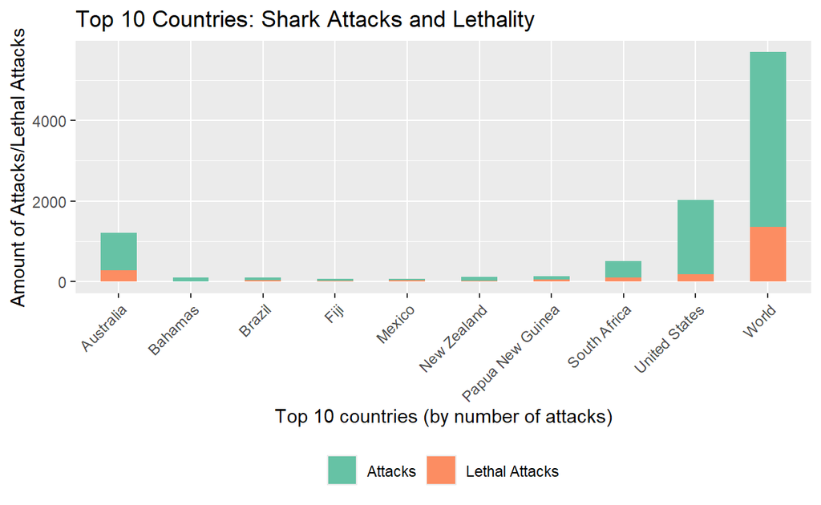

## Final Note

Make sure to push all your commits and changes to GitHub before submittining the exercise sheet.